# Cross-validation scheme 1

Marco Antonio Peixoto, Post doc[^1]

## 1. Genomic selection in a CV1 scheme

In this file I show how to implement a **GBLUP** model in a CV1 scheme using BGLR (Pérez-Rodrı́guez & Los Campos, 2022) in a Single- and Multi-trait framework.

To perform the analyses, we will need the following packages:

```r
rm(list=ls())
require(AGHmatrix)
require(BGLR)
require(tidyverse)
require(dplyr)
require(ggplot2)
```

## 2. Datasets

This dataset was simulated using the coalescent theory implemented in $AlphasimR$ package (Gaynor et al., 2021). IT mimics an evaluation of 500 maize genotypes, in four locations, and four traits were measured. Also, a set of 3000 single nucleotide polymorphism (SNPs) were randomly sampled through the 10 pair of chromosomes.

**Phenotypic data**  
We generated BLUEs (best linear unbiased estimation) for each trait, and it can be loaded from *Phenotypes.csv* file.

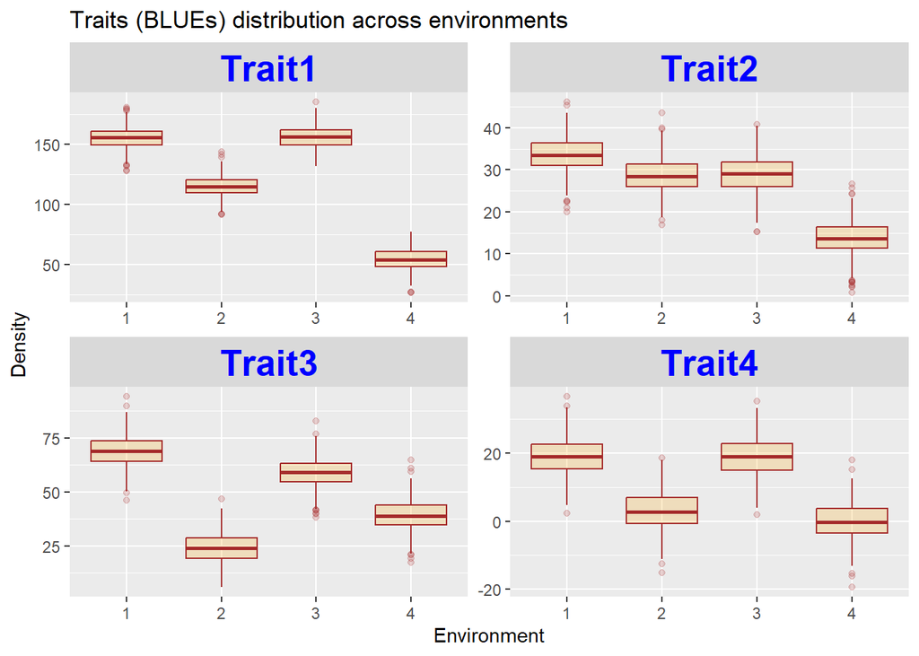

Figure 1. Trait performance over the four environments

```r
#--- 1. Loading the data
Phenotypes = read.csv("Phenotypes.csv")

#--- 2. As factor
Phenotypes$Genotype = Phenotypes$Genotype %>% as.factor
Phenotypes$Env = Phenotypes$Env %>% as.factor

#--- 3. Plotting
Phenotypes[,c(1,3:6)] %>%
  pivot_longer(., cols = c('Trait1','Trait2','Trait3','Trait4')) %>%
ggplot(., aes(x = Env, y = value)) +
  geom_boxplot(color="brown", fill="orange", alpha=0.2) +
  theme(strip.text = element_text(face = "bold", size = 20, colour = 'blue'))+
  labs(x = 'Environment', title = "Traits (BLUEs) distribution across environments",y="Density")+
  facet_wrap(~name,scales = "free")
```

**Genomic data**  
The genomic data (3000 SNP markers) was coded as 0,1,2 for aa,Aa,AA, respectively. The dataset for all 500 genotypes can be loaded from **Genotypes.csv** file.

```r
#--- 1. Loading the SNPs
Genotypes = as.matrix(read.csv("Genotypes.csv"))

#--- 2. Genotypes names
rownames(Genotypes) = unique(Phenotypes$Genotype)
```

**Creating G Matrix**

Here, we will compose the additive relationship matrix (*G* matrix) following the propositions made by VanRaden (2008) in the AGHmatrix package (Amadeu et al., 2016).

```r
#--- 1. Additive matrix
GMat = AGHmatrix::Gmatrix(Genotypes)
```

## 3. Statistical model

**Single-trait model**

The **GBLUP** model in a singletrait framework is given as follows:

$$y = 1u + Za + e$$

where $y$ is the vector of BLUEs data for the target trait; $u$ represents the mean (fixed); $a$ is the vector of genotype effects (assumed to be random), where $a \sim N(0,G\sigma^2_a)$, $G$ is a matrix that describes the genomic similarities between pair of genotypes and $\sigma^2_a$ represents the genetic variance; and $e$ is the vector of residuals (random), where $e\sim N(0,I\sigma^2_{res})$, $\sigma^2_{res}$ is the residual variance. The letter $Z$ refers to the incidence matrix for $a$.

**Multi-trait model**

The **GBLUP** model in a multitrait framework is given as follows:

$$y = 1u + Za + e$$

where $y$ is the matrix of BLUEs data for the target traits; $u$ represents the mean (fixed); $a$ is the matrix of genotype effects (assumed to be random), where $a \sim N(0,\sum_a\otimes G)$, $G$ is a matrix that describes the genomic similarities between pair of genotypes and $\sum_a$ represents the genetic covariance matrix; and $e$ is the residuals (random), where $e\sim N(0,\sum_{res}\otimes I)$, $\sum_{res}$ is the residual covariance matrix. The letter $Z$ refers to the incidence matrix for $a$.

## 4. Single-trait GBLUP using BGLR() function

For this model, we used the trait 1 from the environment 1.

```r
#--- 1. Organizing the phenotypic data
Y<- Phenotypes[Phenotypes$Env == 1,c(1:3)]

#--- 2. Scale the pheno data
y = scale(Y[,3]) # only the trait
```

Deploy the model using the Gmatrix, phenodata and the BGLR() function

```r
#--- 1. Parameters for the folds
nReps = 5 # change here for more repetitions (10-20 is a good fit)
nFolds = 5 # 5 is reasonable, but it depends of or dataset size

#--- 2. Output for the estimated values
yHatCV=rep(NA,length(Y$Trait1))
pred = data.frame()

#--- 3. Model
# Phenodata
y = as.matrix(y)

# Time for the loop
set.seed(0928761)
 for(Rep in 1:nReps){

 folds=sample(1:nFolds,size=length(Y$Trait1),replace=T)

  for(i in 1:max(folds)){
    tst=which(folds==i)
    yNA=y
    yNA[tst]=NA
    # model
    fm=BGLR(y=yNA,
            ETA=list(list(K=GMat,model='RKHS')),
            nIter=1200,
            burnIn=120,
            verbose = FALSE)
    # Predicted values
    yHatCV[tst]=fm$yHat[tst]
  }
 # Accuracy for each fold
 pred=rbind(pred,
            data.frame(Repetitions = Rep,
                       Cor=cor(yHatCV, y)))
}


#--- 4. Mean for the correlation
mean(pred$Cor)
```

## 5. Multi-trait GBLUP using Multitrait() function

To implement this analyses we used trait number 1 over four environments.

```r
#--- Organizing the phenotypic data

Y<- Phenotypes[,c(1,2,3)] %>%
  pivot_wider(., names_from = 'Env', values_from = 'Trait1')

#--- Scale the data
y = scale(Y[,-1])
dim(y)
```

Deploy the model using Multitrait() function.

```r
#--- 1. Parameters for the folds
nReps = 5 # change here for more repetitions (10-20 is a good fit)
nFolds = 5 # 5 is reasonable, but it depends of or dataset size

#--- 2. Output for the estimated values
yHatCV=data.frame(yHat1 = rep(NA,dim(y)[1]),
                  yHat2 = rep(NA,dim(y)[1]),
                  yHat3 = rep(NA,dim(y)[1]),
                  yHat3 = rep(NA,dim(y)[1]))
pred = data.frame()

#--- 3. Model
set.seed(0928761)

for (i in 1:nFolds){

# Partitions for a 5-FCV
folds=sample(1:nFolds,size=dim(y)[1],replace=T)

# Model using multitrait
for(p in 1:nReps){

  tst=which(folds==p)
  yNA=y
  yNA[tst,]=NA

  # Model
  fm <- Multitrait(y=yNA,
                   ETA = list(list(K=GMat,model='RKHS')),
                   resCov = list(type="DIAG"),
                   nIter = 1200,
                   burnIn = 120,
                   saveAt='MGB_',
                   verbose = FALSE)

  yHatCV[tst,] = fm$ETAHat[tst,]
}

# Accuracy for each fold
 pred=rbind(pred,
            data.frame(Fold = i,
                       Cor1=diag(cor(yHatCV,y))[1],
                       Cor2=diag(cor(yHatCV,y))[2],
                       Cor3=diag(cor(yHatCV,y))[3],
                       Cor4=diag(cor(yHatCV,y))[4]))

}

pred


#--- 4. Extracting estimates of variance parameters
(CORB.RES<-fm$resCov$R) # residual covariance matrix
(CORB.u<-fm$ETA[[1]]$Cov$Omega) # genetic covariance matrix UE

#--- 5. Trait correlation
cov2cor(CORB.u)
```

## 6. Multi-trait GBLUP using Multitrait() function

Now, lets use the information of 4 traits in just one environment (number 4).

```r
#--- 1. Organizing the phenotypic data
Y<- Phenotypes[Phenotypes$Env == 4,]

#--- 2. Scale the pheno data
y = scale(Y[,-c(1:2)])
```

Deploy the model using Multitrait() function.

```r
#--- 1. Parameters for the folds
nReps = 5 # change here for more repetitions (10-20 is a good fit)
nFolds = 5 # 5 is reasonable, but it depends of or dataset size

#--- 2. Output for the estimated values
yHatCV=data.frame(yHat1 = rep(NA,dim(y)[1]),
                  yHat2 = rep(NA,dim(y)[1]),
                  yHat3 = rep(NA,dim(y)[1]),
                  yHat3 = rep(NA,dim(y)[1]))

pred = data.frame()

#--- 3. Model
set.seed(0928761)

for (i in 1:nFolds){

# Partitions for a 5-FCV
folds=sample(1:nFolds,size=dim(y)[1],replace=T)

# Model using multitrait
for(p in 1:nReps){

  tst=which(folds==p)
  yNA=y
  yNA[tst]=NA

  fm <- Multitrait(y=yNA,
                   ETA = list(list(K=GMat,model='RKHS')),
                   resCov = list(type="DIAG"),
                   nIter = 1200,
                   burnIn = 120,
                   saveAt='MGB_',
                   verbose = FALSE)

  yHatCV[tst,] = fm$ETAHat[tst,]
}

# Accuracy for each fold
 pred=rbind(pred,
            data.frame(Fold = i,
                       Cor1=diag(cor(yHatCV,y))[1],
                       Cor2=diag(cor(yHatCV,y))[2],
                       Cor3=diag(cor(yHatCV,y))[3],
                       Cor4=diag(cor(yHatCV,y))[4]))
}

pred

#--- 4. Extracting estimates of variance parameters
(CORB.RES<-fm$resCov$R) # residual covariance matrix
(CORB.u<-fm$ETA[[1]]$Cov$Omega) # genetic covariance matrix UE

#--- 5. Trait correlation
cov2cor(CORB.u)
```

## References

Amadeu, R. R., Cellon, C., Olmstead, J. W., Garcia, A. A., Resende Jr, M. F., & Muñoz, P. R. (2016). AGHmatrix: R package to construct relationship matrices for autotetraploid and diploid species: A blueberry example. *The Plant Genome*, *9*(3), plantgenome2016–01.

Gaynor, R. C., Gorjanc, G., & Hickey, J. M. (2021). AlphaSimR: An r package for breeding program simulations. *G3*, *11*(2), jkaa017.

Pérez-Rodrı́guez, P., & Los Campos, G. de. (2022). Multitrait bayesian shrinkage and variable selection models with the BGLR-r package. *Genetics*, *222*(1), iyac112.

VanRaden, P. M. (2008). Efficient methods to compute genomic predictions. *Journal of Dairy Science*, *91*(11), 4414–4423.

[^1]: University of Florida, deamorimpeixotom@ufl.edu